# Risk Factor Analysis

## Outcome Variable

**Outcome Variable:** haz

## Predictor Variables

**Intervention Variable:** impsan

**Adjustment Set:**

unadjusted

## Stratifying Variables

The analysis was stratified on these variable(s):

- agecat
- studyid
- country

## Data Summary

| agecat | studyid | country | impsan | n_cell | n |
| --- | --- | --- | --- | --- | --- |
| Birth | ki0047075b-MAL-ED | BANGLADESH | 1 | 197 | 234 |
| Birth | ki0047075b-MAL-ED | BANGLADESH | 0 | 37 | 234 |
| Birth | ki0047075b-MAL-ED | BRAZIL | 1 | 170 | 174 |
| Birth | ki0047075b-MAL-ED | BRAZIL | 0 | 4 | 174 |
| Birth | ki0047075b-MAL-ED | INDIA | 1 | 92 | 190 |
| Birth | ki0047075b-MAL-ED | INDIA | 0 | 98 | 190 |
| Birth | ki0047075b-MAL-ED | NEPAL | 1 | 170 | 171 |
| Birth | ki0047075b-MAL-ED | NEPAL | 0 | 1 | 171 |
| Birth | ki0047075b-MAL-ED | PERU | 1 | 62 | 250 |
| Birth | ki0047075b-MAL-ED | PERU | 0 | 188 | 250 |
| Birth | ki0047075b-MAL-ED | SOUTH AFRICA | 1 | 2 | 213 |
| Birth | ki0047075b-MAL-ED | SOUTH AFRICA | 0 | 211 | 213 |
| Birth | ki0047075b-MAL-ED | TANZANIA, UNITED REPUBLIC OF | 1 | 0 | 113 |
| Birth | ki0047075b-MAL-ED | TANZANIA, UNITED REPUBLIC OF | 0 | 113 | 113 |
| Birth | ki1017093-NIH-Birth | BANGLADESH | 1 | 9 | 28 |
| Birth | ki1017093-NIH-Birth | BANGLADESH | 0 | 19 | 28 |
| Birth | ki1017093c-NIH-Crypto | BANGLADESH | 1 | 25 | 27 |
| Birth | ki1017093c-NIH-Crypto | BANGLADESH | 0 | 2 | 27 |
| Birth | ki1114097-CONTENT | PERU | 1 | 1 | 2 |
| Birth | ki1114097-CONTENT | PERU | 0 | 1 | 2 |
| Birth | ki1135781-COHORTS | GUATEMALA | 1 | 45 | 491 |
| Birth | ki1135781-COHORTS | GUATEMALA | 0 | 446 | 491 |
| Birth | ki1135781-COHORTS | INDIA | 1 | 1767 | 4776 |
| Birth | ki1135781-COHORTS | INDIA | 0 | 3009 | 4776 |
| Birth | ki1135781-COHORTS | PHILIPPINES | 1 | 178 | 1191 |
| Birth | ki1135781-COHORTS | PHILIPPINES | 0 | 1013 | 1191 |
| Birth | kiGH5241-JiVitA-3 | BANGLADESH | 1 | 13187 | 19592 |
| Birth | kiGH5241-JiVitA-3 | BANGLADESH | 0 | 6405 | 19592 |
| Birth | kiGH5241-JiVitA-4 | BANGLADESH | 1 | 606 | 822 |
| Birth | kiGH5241-JiVitA-4 | BANGLADESH | 0 | 216 | 822 |

[output cut: 68 more lines]

The following strata were considered:

- agecat: 24 months, studyid: ki0047075b-MAL-ED, country: BANGLADESH
- agecat: 24 months, studyid: ki0047075b-MAL-ED, country: BRAZIL
- agecat: 24 months, studyid: ki0047075b-MAL-ED, country: INDIA
- agecat: 24 months, studyid: ki0047075b-MAL-ED, country: NEPAL
- agecat: 24 months, studyid: ki0047075b-MAL-ED, country: PERU
- agecat: 24 months, studyid: ki0047075b-MAL-ED, country: SOUTH AFRICA
- agecat: 24 months, studyid: ki0047075b-MAL-ED, country: TANZANIA, UNITED REPUBLIC OF
- agecat: 24 months, studyid: ki1017093-NIH-Birth, country: BANGLADESH
- agecat: 24 months, studyid: ki1017093b-PROVIDE, country: BANGLADESH
- agecat: 24 months, studyid: ki1017093c-NIH-Crypto, country: BANGLADESH
- agecat: 24 months, studyid: ki1114097-CONTENT, country: PERU
- agecat: 24 months, studyid: ki1135781-COHORTS, country: GUATEMALA
- agecat: 24 months, studyid: ki1135781-COHORTS, country: INDIA
- agecat: 24 months, studyid: ki1135781-COHORTS, country: PHILIPPINES
- agecat: 24 months, studyid: ki1148112-LCNI-5, country: MALAWI
- agecat: 24 months, studyid: kiGH5241-JiVitA-3, country: BANGLADESH
- agecat: 24 months, studyid: kiGH5241-JiVitA-4, country: BANGLADESH
- agecat: 6 months, studyid: ki0047075b-MAL-ED, country: BANGLADESH
- agecat: 6 months, studyid: ki0047075b-MAL-ED, country: BRAZIL
- agecat: 6 months, studyid: ki0047075b-MAL-ED, country: INDIA
- agecat: 6 months, studyid: ki0047075b-MAL-ED, country: NEPAL
- agecat: 6 months, studyid: ki0047075b-MAL-ED, country: PERU
- agecat: 6 months, studyid: ki0047075b-MAL-ED, country: SOUTH AFRICA
- agecat: 6 months, studyid: ki0047075b-MAL-ED, country: TANZANIA, UNITED REPUBLIC OF
- agecat: 6 months, studyid: ki1017093-NIH-Birth, country: BANGLADESH
- agecat: 6 months, studyid: ki1017093b-PROVIDE, country: BANGLADESH
- agecat: 6 months, studyid: ki1017093c-NIH-Crypto, country: BANGLADESH
- agecat: 6 months, studyid: ki1114097-CONTENT, country: PERU
- agecat: 6 months, studyid: ki1135781-COHORTS, country: GUATEMALA
- agecat: 6 months, studyid: ki1135781-COHORTS, country: INDIA
- agecat: 6 months, studyid: ki1135781-COHORTS, country: PHILIPPINES
- agecat: 6 months, studyid: ki1148112-LCNI-5, country: MALAWI
- agecat: 6 months, studyid: kiGH5241-JiVitA-3, country: BANGLADESH
- agecat: 6 months, studyid: kiGH5241-JiVitA-4, country: BANGLADESH
- agecat: Birth, studyid: ki0047075b-MAL-ED, country: BANGLADESH
- agecat: Birth, studyid: ki0047075b-MAL-ED, country: BRAZIL
- agecat: Birth, studyid: ki0047075b-MAL-ED, country: INDIA
- agecat: Birth, studyid: ki0047075b-MAL-ED, country: NEPAL
- agecat: Birth, studyid: ki0047075b-MAL-ED, country: PERU
- agecat: Birth, studyid: ki0047075b-MAL-ED, country: SOUTH AFRICA
- agecat: Birth, studyid: ki0047075b-MAL-ED, country: TANZANIA, UNITED REPUBLIC OF
- agecat: Birth, studyid: ki1017093-NIH-Birth, country: BANGLADESH
- agecat: Birth, studyid: ki1017093c-NIH-Crypto, country: BANGLADESH
- agecat: Birth, studyid: ki1114097-CONTENT, country: PERU
- agecat: Birth, studyid: ki1135781-COHORTS, country: GUATEMALA
- agecat: Birth, studyid: ki1135781-COHORTS, country: INDIA
- agecat: Birth, studyid: ki1135781-COHORTS, country: PHILIPPINES
- agecat: Birth, studyid: kiGH5241-JiVitA-3, country: BANGLADESH
- agecat: Birth, studyid: kiGH5241-JiVitA-4, country: BANGLADESH

### Dropped Strata

Some strata were dropped due to rare outcomes:

- agecat: Birth, studyid: ki0047075b-MAL-ED, country: BRAZIL
- agecat: Birth, studyid: ki0047075b-MAL-ED, country: NEPAL
- agecat: Birth, studyid: ki0047075b-MAL-ED, country: SOUTH AFRICA
- agecat: Birth, studyid: ki0047075b-MAL-ED, country: TANZANIA, UNITED REPUBLIC OF
- agecat: Birth, studyid: ki1017093c-NIH-Crypto, country: BANGLADESH
- agecat: Birth, studyid: ki1114097-CONTENT, country: PERU
- agecat: 6 months, studyid: ki0047075b-MAL-ED, country: BRAZIL
- agecat: 6 months, studyid: ki0047075b-MAL-ED, country: NEPAL
- agecat: 6 months, studyid: ki0047075b-MAL-ED, country: SOUTH AFRICA
- agecat: 6 months, studyid: ki0047075b-MAL-ED, country: TANZANIA, UNITED REPUBLIC OF
- agecat: 6 months, studyid: ki1148112-LCNI-5, country: MALAWI
- agecat: 24 months, studyid: ki0047075b-MAL-ED, country: BRAZIL
- agecat: 24 months, studyid: ki0047075b-MAL-ED, country: NEPAL
- agecat: 24 months, studyid: ki0047075b-MAL-ED, country: SOUTH AFRICA
- agecat: 24 months, studyid: ki0047075b-MAL-ED, country: TANZANIA, UNITED REPUBLIC OF
- agecat: 24 months, studyid: ki1148112-LCNI-5, country: MALAWI

## Methods Detail

We’re interested in the causal parameters $E[Y_a]$ for all values of $a \in \mathcal{A}$. These parameters represent the mean outcome if, possibly contrary to fact, we intervened to set all units to have $A=a$. Under the randomization and positivity assumptions, these are identified by the statistical parameters $\psi_a=E_W[E_{Y|A,W}(Y|A=a,W)]$. In addition, we’re interested in the mean of $Y$, $E[Y]$ under no intervention (the observed mean). We will estimate these parameters by using SuperLearner to fit the relevant likelihood factors – $E_{Y|A,W}(Y|A=a,W)$ and $p(A=a|W)$, and then updating our likelihood fit using a joint TMLE.

For unadjusted analyses ($W=\{\}$), initial likelihoods were estimated using Lrnr_glm to estimate the simple $E(Y|A)$ and Lrnr_mean to estimate $p(A)$. For adjusted analyses, a small library containing Lrnr_glmnet, Lrnr_xgboost, and Lrnr_mean was used.

Having estimated these parameters, we will then use the delta method to estimate relative risks and attributable risks relative to a prespecified baseline level of $A$.

# Results Detail

## Results Plots

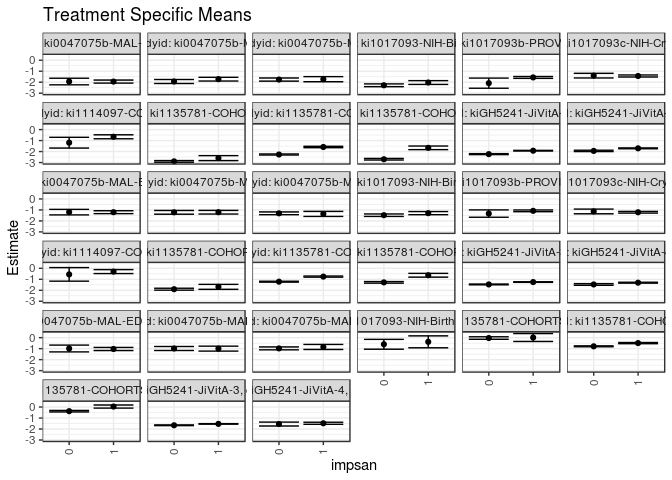

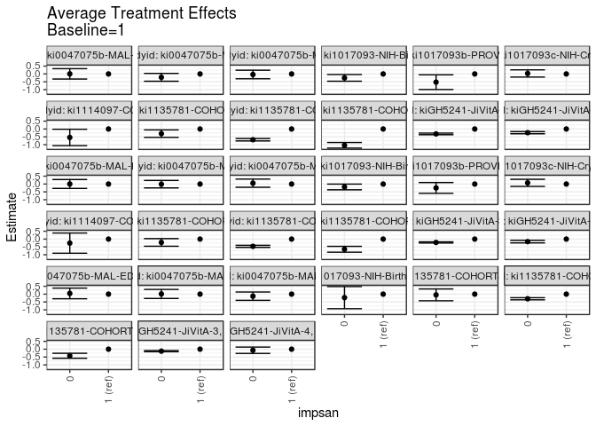

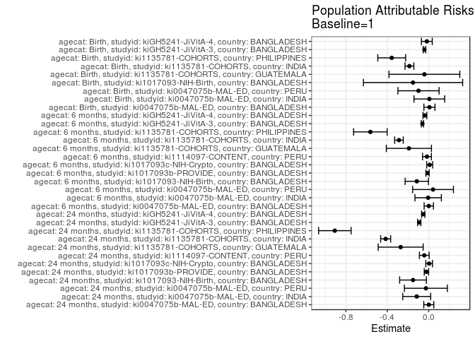

## Results Table

### Parameter: TSM

| agecat | studyid | country | intervention_level | baseline_level | estimate | ci_lower | ci_upper |
| --- | --- | --- | --- | --- | --- | --- | --- |
| Birth | ki0047075b-MAL-ED | BANGLADESH | 1 | NA | -1.0300000 | -1.1705898 | -0.8894102 |
| Birth | ki0047075b-MAL-ED | BANGLADESH | 0 | NA | -0.9854054 | -1.2934742 | -0.6773366 |
| Birth | ki0047075b-MAL-ED | INDIA | 1 | NA | -0.9977174 | -1.2204348 | -0.7750000 |
| Birth | ki0047075b-MAL-ED | INDIA | 0 | NA | -0.9852041 | -1.1672896 | -0.8031185 |
| Birth | ki0047075b-MAL-ED | PERU | 1 | NA | -0.8446774 | -1.0734612 | -0.6158936 |
| Birth | ki0047075b-MAL-ED | PERU | 0 | NA | -0.9754255 | -1.1083105 | -0.8425405 |
| Birth | ki1017093-NIH-Birth | BANGLADESH | 1 | NA | -0.3777778 | -0.9207364 | 0.1651808 |
| Birth | ki1017093-NIH-Birth | BANGLADESH | 0 | NA | -0.6010526 | -1.0492335 | -0.1528718 |
| Birth | ki1135781-COHORTS | GUATEMALA | 1 | NA | 0.0140000 | -0.3450346 | 0.3730346 |
| Birth | ki1135781-COHORTS | GUATEMALA | 0 | NA | -0.0317265 | -0.1454192 | 0.0819663 |
| Birth | ki1135781-COHORTS | INDIA | 1 | NA | -0.4914658 | -0.5448741 | -0.4380574 |
| Birth | ki1135781-COHORTS | INDIA | 0 | NA | -0.7870821 | -0.8283252 | -0.7458390 |
| Birth | ki1135781-COHORTS | PHILIPPINES | 1 | NA | 0.0435393 | -0.0987359 | 0.1858146 |
| Birth | ki1135781-COHORTS | PHILIPPINES | 0 | NA | -0.3765153 | -0.4451537 | -0.3078769 |
| Birth | kiGH5241-JiVitA-3 | BANGLADESH | 1 | NA | -1.5339941 | -1.5576028 | -1.5103854 |
| Birth | kiGH5241-JiVitA-3 | BANGLADESH | 0 | NA | -1.6599750 | -1.6907459 | -1.6292041 |
| Birth | kiGH5241-JiVitA-4 | BANGLADESH | 1 | NA | -1.4794389 | -1.5735859 | -1.3852920 |
| Birth | kiGH5241-JiVitA-4 | BANGLADESH | 0 | NA | -1.5487963 | -1.7272851 | -1.3703075 |
| 6 months | ki0047075b-MAL-ED | BANGLADESH | 1 | NA | -1.2041419 | -1.3360168 | -1.0722671 |
| 6 months | ki0047075b-MAL-ED | BANGLADESH | 0 | NA | -1.1992544 | -1.4498728 | -0.9486360 |
| 6 months | ki0047075b-MAL-ED | INDIA | 1 | NA | -1.2085185 | -1.3744231 | -1.0426139 |
| 6 months | ki0047075b-MAL-ED | INDIA | 0 | NA | -1.2182133 | -1.3883587 | -1.0480680 |
| 6 months | ki0047075b-MAL-ED | PERU | 1 | NA | -1.3629231 | -1.5928372 | -1.1330090 |
| 6 months | ki0047075b-MAL-ED | PERU | 0 | NA | -1.3072811 | -1.4324386 | -1.1821237 |
| 6 months | ki1017093-NIH-Birth | BANGLADESH | 1 | NA | -1.2924553 | -1.4351827 | -1.1497279 |
| 6 months | ki1017093-NIH-Birth | BANGLADESH | 0 | NA | -1.4783459 | -1.5908332 | -1.3658586 |
| 6 months | ki1017093b-PROVIDE | BANGLADESH | 1 | NA | -1.0814715 | -1.1594273 | -1.0035157 |
| 6 months | ki1017093b-PROVIDE | BANGLADESH | 0 | NA | -1.3294231 | -1.6640042 | -0.9948419 |
| 6 months | ki1017093c-NIH-Crypto | BANGLADESH | 1 | NA | -1.2126829 | -1.2888615 | -1.1365043 |
| 6 months | ki1017093c-NIH-Crypto | BANGLADESH | 0 | NA | -1.1369101 | -1.3508747 | -0.9229455 |
| 6 months | ki1114097-CONTENT | PERU | 1 | NA | -0.2972521 | -0.4769295 | -0.1175747 |
| 6 months | ki1114097-CONTENT | PERU | 0 | NA | -0.5532500 | -1.1705359 | 0.0640359 |
| 6 months | ki1135781-COHORTS | GUATEMALA | 1 | NA | -1.6874627 | -1.9137285 | -1.4611969 |
| 6 months | ki1135781-COHORTS | GUATEMALA | 0 | NA | -1.9006261 | -1.9881552 | -1.8130969 |
| 6 months | ki1135781-COHORTS | INDIA | 1 | NA | -0.7542743 | -0.8056832 | -0.7028654 |
| 6 months | ki1135781-COHORTS | INDIA | 0 | NA | -1.2162524 | -1.2572688 | -1.1752361 |
| 6 months | ki1135781-COHORTS | PHILIPPINES | 1 | NA | -0.6306993 | -0.8028673 | -0.4585313 |
| 6 months | ki1135781-COHORTS | PHILIPPINES | 0 | NA | -1.2800319 | -1.3505196 | -1.2095442 |
| 6 months | kiGH5241-JiVitA-3 | BANGLADESH | 1 | NA | -1.2526857 | -1.2783672 | -1.2270041 |
| 6 months | kiGH5241-JiVitA-3 | BANGLADESH | 0 | NA | -1.4671651 | -1.5012388 | -1.4330913 |
| 6 months | kiGH5241-JiVitA-4 | BANGLADESH | 1 | NA | -1.3073889 | -1.3492812 | -1.2654965 |
| 6 months | kiGH5241-JiVitA-4 | BANGLADESH | 0 | NA | -1.4695142 | -1.5422678 | -1.3967606 |
| 24 months | ki0047075b-MAL-ED | BANGLADESH | 1 | NA | -1.9438674 | -2.0822441 | -1.8054907 |
| 24 months | ki0047075b-MAL-ED | BANGLADESH | 0 | NA | -1.9387097 | -2.2393083 | -1.6381111 |
| 24 months | ki0047075b-MAL-ED | INDIA | 1 | NA | -1.7216827 | -1.8914539 | -1.5519115 |
| 24 months | ki0047075b-MAL-ED | INDIA | 0 | NA | -1.9365289 | -2.1193641 | -1.7536938 |
| 24 months | ki0047075b-MAL-ED | PERU | 1 | NA | -1.7242553 | -1.9566331 | -1.4918776 |
| 24 months | ki0047075b-MAL-ED | PERU | 0 | NA | -1.7600000 | -1.9025069 | -1.6174931 |
| 24 months | ki1017093-NIH-Birth | BANGLADESH | 1 | NA | -2.0295000 | -2.2015259 | -1.8574741 |
| 24 months | ki1017093-NIH-Birth | BANGLADESH | 0 | NA | -2.2800997 | -2.4060834 | -2.1541161 |
| 24 months | ki1017093b-PROVIDE | BANGLADESH | 1 | NA | -1.5635507 | -1.6477558 | -1.4793457 |
| 24 months | ki1017093b-PROVIDE | BANGLADESH | 0 | NA | -2.0879167 | -2.5478363 | -1.6279970 |
| 24 months | ki1017093c-NIH-Crypto | BANGLADESH | 1 | NA | -1.4340647 | -1.5257819 | -1.3423474 |
| 24 months | ki1017093c-NIH-Crypto | BANGLADESH | 0 | NA | -1.4028571 | -1.6140474 | -1.1916669 |
| 24 months | ki1114097-CONTENT | PERU | 1 | NA | -0.6535762 | -0.8330310 | -0.4741214 |
| 24 months | ki1114097-CONTENT | PERU | 0 | NA | -1.1915385 | -1.6813725 | -0.7017044 |
| 24 months | ki1135781-COHORTS | GUATEMALA | 1 | NA | -2.5967532 | -2.8224746 | -2.3710319 |
| 24 months | ki1135781-COHORTS | GUATEMALA | 0 | NA | -2.8929304 | -2.9672260 | -2.8186349 |
| 24 months | ki1135781-COHORTS | INDIA | 1 | NA | -1.5844731 | -1.6444930 | -1.5244533 |
| 24 months | ki1135781-COHORTS | INDIA | 0 | NA | -2.2683574 | -2.3170051 | -2.2197098 |
| 24 months | ki1135781-COHORTS | PHILIPPINES | 1 | NA | -1.6612698 | -1.8245141 | -1.4980256 |
| 24 months | ki1135781-COHORTS | PHILIPPINES | 0 | NA | -2.7003472 | -2.7715528 | -2.6291417 |
| 24 months | kiGH5241-JiVitA-3 | BANGLADESH | 1 | NA | -1.9214662 | -1.9532502 | -1.8896822 |
| 24 months | kiGH5241-JiVitA-3 | BANGLADESH | 0 | NA | -2.2347153 | -2.2783315 | -2.1910990 |
| 24 months | kiGH5241-JiVitA-4 | BANGLADESH | 1 | NA | -1.7051588 | -1.7456931 | -1.6646245 |
| 24 months | kiGH5241-JiVitA-4 | BANGLADESH | 0 | NA | -1.9404323 | -2.0002556 | -1.8806091 |

### Parameter: E(Y)

| agecat | studyid | country | intervention_level | baseline_level | estimate | ci_lower | ci_upper |
| --- | --- | --- | --- | --- | --- | --- | --- |
| Birth | ki0047075b-MAL-ED | BANGLADESH | NA | NA | -1.0229487 | -1.1509575 | -0.8949400 |
| Birth | ki0047075b-MAL-ED | INDIA | NA | NA | -0.9912632 | -1.1342711 | -0.8482552 |
| Birth | ki0047075b-MAL-ED | PERU | NA | NA | -0.9430000 | -1.0581275 | -0.8278725 |
| Birth | ki1017093-NIH-Birth | BANGLADESH | NA | NA | -0.5292857 | -0.8821252 | -0.1764462 |
| Birth | ki1135781-COHORTS | GUATEMALA | NA | NA | -0.0275356 | -0.1359303 | 0.0808590 |
| Birth | ki1135781-COHORTS | INDIA | NA | NA | -0.6777115 | -0.7106054 | -0.6448175 |
| Birth | ki1135781-COHORTS | PHILIPPINES | NA | NA | -0.3137364 | -0.3764483 | -0.2510244 |
| Birth | kiGH5241-JiVitA-3 | BANGLADESH | NA | NA | -1.5751797 | -1.5949356 | -1.5554237 |
| Birth | kiGH5241-JiVitA-4 | BANGLADESH | NA | NA | -1.4976642 | -1.5817349 | -1.4135935 |
| 6 months | ki0047075b-MAL-ED | BANGLADESH | NA | NA | -1.2033681 | -1.3212429 | -1.0854932 |
| 6 months | ki0047075b-MAL-ED | INDIA | NA | NA | -1.2137196 | -1.3330761 | -1.0943631 |
| 6 months | ki0047075b-MAL-ED | PERU | NA | NA | -1.3210330 | -1.4311040 | -1.2109619 |
| 6 months | ki1017093-NIH-Birth | BANGLADESH | NA | NA | -1.4073821 | -1.4960598 | -1.3187043 |
| 6 months | ki1017093b-PROVIDE | BANGLADESH | NA | NA | -1.0925674 | -1.1686395 | -1.0164954 |
| 6 months | ki1017093c-NIH-Crypto | BANGLADESH | NA | NA | -1.2031037 | -1.2749632 | -1.1312442 |
| 6 months | ki1114097-CONTENT | PERU | NA | NA | -0.3139217 | -0.4868486 | -0.1409948 |
| 6 months | ki1135781-COHORTS | GUATEMALA | NA | NA | -1.8789210 | -1.9609921 | -1.7968498 |
| 6 months | ki1135781-COHORTS | INDIA | NA | NA | -1.0414424 | -1.0741113 | -1.0087734 |
| 6 months | ki1135781-COHORTS | PHILIPPINES | NA | NA | -1.1942936 | -1.2608624 | -1.1277248 |
| 6 months | kiGH5241-JiVitA-3 | BANGLADESH | NA | NA | -1.3134804 | -1.3366079 | -1.2903528 |
| 6 months | kiGH5241-JiVitA-4 | BANGLADESH | NA | NA | -1.3440477 | -1.3813060 | -1.3067894 |
| 24 months | ki0047075b-MAL-ED | BANGLADESH | NA | NA | -1.9431132 | -2.0691678 | -1.8170586 |
| 24 months | ki0047075b-MAL-ED | INDIA | NA | NA | -1.8372222 | -1.9638017 | -1.7106427 |
| 24 months | ki0047075b-MAL-ED | PERU | NA | NA | -1.7514286 | -1.8732727 | -1.6295845 |
| 24 months | ki1017093-NIH-Birth | BANGLADESH | NA | NA | -2.1807945 | -2.2835902 | -2.0779987 |
| 24 months | ki1017093b-PROVIDE | BANGLADESH | NA | NA | -1.5853993 | -1.6687810 | -1.5020176 |
| 24 months | ki1017093c-NIH-Crypto | BANGLADESH | NA | NA | -1.4297217 | -1.5139732 | -1.3454701 |
| 24 months | ki1114097-CONTENT | PERU | NA | NA | -0.6962195 | -0.8674103 | -0.5250287 |
| 24 months | ki1135781-COHORTS | GUATEMALA | NA | NA | -2.8674777 | -2.9383136 | -2.7966417 |
| 24 months | ki1135781-COHORTS | INDIA | NA | NA | -2.0003783 | -2.0396528 | -1.9611037 |
| 24 months | ki1135781-COHORTS | PHILIPPINES | NA | NA | -2.5681010 | -2.6370882 | -2.4991138 |
| 24 months | kiGH5241-JiVitA-3 | BANGLADESH | NA | NA | -2.0126943 | -2.0403978 | -1.9849907 |
| 24 months | kiGH5241-JiVitA-4 | BANGLADESH | NA | NA | -1.7578934 | -1.7933205 | -1.7224663 |

### Parameter: ATE

| agecat | studyid | country | intervention_level | baseline_level | estimate | ci_lower | ci_upper |
| --- | --- | --- | --- | --- | --- | --- | --- |
| Birth | ki0047075b-MAL-ED | BANGLADESH | 1 | 1 | 0.0000000 | 0.0000000 | 0.0000000 |
| Birth | ki0047075b-MAL-ED | BANGLADESH | 0 | 1 | 0.0445946 | -0.2940377 | 0.3832269 |
| Birth | ki0047075b-MAL-ED | INDIA | 1 | 1 | 0.0000000 | 0.0000000 | 0.0000000 |
| Birth | ki0047075b-MAL-ED | INDIA | 0 | 1 | 0.0125133 | -0.2751639 | 0.3001905 |
| Birth | ki0047075b-MAL-ED | PERU | 1 | 1 | 0.0000000 | 0.0000000 | 0.0000000 |
| Birth | ki0047075b-MAL-ED | PERU | 0 | 1 | -0.1307481 | -0.3953241 | 0.1338279 |
| Birth | ki1017093-NIH-Birth | BANGLADESH | 1 | 1 | 0.0000000 | 0.0000000 | 0.0000000 |
| Birth | ki1017093-NIH-Birth | BANGLADESH | 0 | 1 | -0.2232749 | -0.9273133 | 0.4807636 |
| Birth | ki1135781-COHORTS | GUATEMALA | 1 | 1 | 0.0000000 | 0.0000000 | 0.0000000 |
| Birth | ki1135781-COHORTS | GUATEMALA | 0 | 1 | -0.0457265 | -0.4223322 | 0.3308793 |
| Birth | ki1135781-COHORTS | INDIA | 1 | 1 | 0.0000000 | 0.0000000 | 0.0000000 |
| Birth | ki1135781-COHORTS | INDIA | 0 | 1 | -0.2956163 | -0.3630956 | -0.2281371 |
| Birth | ki1135781-COHORTS | PHILIPPINES | 1 | 1 | 0.0000000 | 0.0000000 | 0.0000000 |
| Birth | ki1135781-COHORTS | PHILIPPINES | 0 | 1 | -0.4200546 | -0.5780214 | -0.2620879 |
| Birth | kiGH5241-JiVitA-3 | BANGLADESH | 1 | 1 | 0.0000000 | 0.0000000 | 0.0000000 |
| Birth | kiGH5241-JiVitA-3 | BANGLADESH | 0 | 1 | -0.1259809 | -0.1628228 | -0.0891390 |
| Birth | kiGH5241-JiVitA-4 | BANGLADESH | 1 | 1 | 0.0000000 | 0.0000000 | 0.0000000 |
| Birth | kiGH5241-JiVitA-4 | BANGLADESH | 0 | 1 | -0.0693574 | -0.2703037 | 0.1315890 |
| 6 months | ki0047075b-MAL-ED | BANGLADESH | 1 | 1 | 0.0000000 | 0.0000000 | 0.0000000 |
| 6 months | ki0047075b-MAL-ED | BANGLADESH | 0 | 1 | 0.0048875 | -0.2783095 | 0.2880846 |
| 6 months | ki0047075b-MAL-ED | INDIA | 1 | 1 | 0.0000000 | 0.0000000 | 0.0000000 |
| 6 months | ki0047075b-MAL-ED | INDIA | 0 | 1 | -0.0096948 | -0.2473369 | 0.2279473 |
| 6 months | ki0047075b-MAL-ED | PERU | 1 | 1 | 0.0000000 | 0.0000000 | 0.0000000 |
| 6 months | ki0047075b-MAL-ED | PERU | 0 | 1 | 0.0556419 | -0.2061306 | 0.3174145 |
| 6 months | ki1017093-NIH-Birth | BANGLADESH | 1 | 1 | 0.0000000 | 0.0000000 | 0.0000000 |
| 6 months | ki1017093-NIH-Birth | BANGLADESH | 0 | 1 | -0.1858906 | -0.3676170 | -0.0041642 |
| 6 months | ki1017093b-PROVIDE | BANGLADESH | 1 | 1 | 0.0000000 | 0.0000000 | 0.0000000 |
| 6 months | ki1017093b-PROVIDE | BANGLADESH | 0 | 1 | -0.2479516 | -0.5914944 | 0.0955912 |
| 6 months | ki1017093c-NIH-Crypto | BANGLADESH | 1 | 1 | 0.0000000 | 0.0000000 | 0.0000000 |
| 6 months | ki1017093c-NIH-Crypto | BANGLADESH | 0 | 1 | 0.0757728 | -0.1513484 | 0.3028940 |
| 6 months | ki1114097-CONTENT | PERU | 1 | 1 | 0.0000000 | 0.0000000 | 0.0000000 |
| 6 months | ki1114097-CONTENT | PERU | 0 | 1 | -0.2559979 | -0.8989022 | 0.3869063 |
| 6 months | ki1135781-COHORTS | GUATEMALA | 1 | 1 | 0.0000000 | 0.0000000 | 0.0000000 |
| 6 months | ki1135781-COHORTS | GUATEMALA | 0 | 1 | -0.2131634 | -0.4557692 | 0.0294424 |
| 6 months | ki1135781-COHORTS | INDIA | 1 | 1 | 0.0000000 | 0.0000000 | 0.0000000 |
| 6 months | ki1135781-COHORTS | INDIA | 0 | 1 | -0.4619781 | -0.5277445 | -0.3962117 |
| 6 months | ki1135781-COHORTS | PHILIPPINES | 1 | 1 | 0.0000000 | 0.0000000 | 0.0000000 |
| 6 months | ki1135781-COHORTS | PHILIPPINES | 0 | 1 | -0.6493326 | -0.8353711 | -0.4632941 |
| 6 months | kiGH5241-JiVitA-3 | BANGLADESH | 1 | 1 | 0.0000000 | 0.0000000 | 0.0000000 |
| 6 months | kiGH5241-JiVitA-3 | BANGLADESH | 0 | 1 | -0.2144794 | -0.2520130 | -0.1769458 |
| 6 months | kiGH5241-JiVitA-4 | BANGLADESH | 1 | 1 | 0.0000000 | 0.0000000 | 0.0000000 |
| 6 months | kiGH5241-JiVitA-4 | BANGLADESH | 0 | 1 | -0.1621253 | -0.2443124 | -0.0799383 |
| 24 months | ki0047075b-MAL-ED | BANGLADESH | 1 | 1 | 0.0000000 | 0.0000000 | 0.0000000 |
| 24 months | ki0047075b-MAL-ED | BANGLADESH | 0 | 1 | 0.0051577 | -0.3257617 | 0.3360771 |
| 24 months | ki0047075b-MAL-ED | INDIA | 1 | 1 | 0.0000000 | 0.0000000 | 0.0000000 |
| 24 months | ki0047075b-MAL-ED | INDIA | 0 | 1 | -0.2148462 | -0.4643476 | 0.0346552 |
| 24 months | ki0047075b-MAL-ED | PERU | 1 | 1 | 0.0000000 | 0.0000000 | 0.0000000 |
| 24 months | ki0047075b-MAL-ED | PERU | 0 | 1 | -0.0357447 | -0.3083389 | 0.2368496 |
| 24 months | ki1017093-NIH-Birth | BANGLADESH | 1 | 1 | 0.0000000 | 0.0000000 | 0.0000000 |
| 24 months | ki1017093-NIH-Birth | BANGLADESH | 0 | 1 | -0.2505997 | -0.4638245 | -0.0373750 |
| 24 months | ki1017093b-PROVIDE | BANGLADESH | 1 | 1 | 0.0000000 | 0.0000000 | 0.0000000 |
| 24 months | ki1017093b-PROVIDE | BANGLADESH | 0 | 1 | -0.5243659 | -0.9919304 | -0.0568015 |
| 24 months | ki1017093c-NIH-Crypto | BANGLADESH | 1 | 1 | 0.0000000 | 0.0000000 | 0.0000000 |
| 24 months | ki1017093c-NIH-Crypto | BANGLADESH | 0 | 1 | 0.0312075 | -0.1990388 | 0.2614538 |
| 24 months | ki1114097-CONTENT | PERU | 1 | 1 | 0.0000000 | 0.0000000 | 0.0000000 |
| 24 months | ki1114097-CONTENT | PERU | 0 | 1 | -0.5379623 | -1.0596340 | -0.0162906 |
| 24 months | ki1135781-COHORTS | GUATEMALA | 1 | 1 | 0.0000000 | 0.0000000 | 0.0000000 |
| 24 months | ki1135781-COHORTS | GUATEMALA | 0 | 1 | -0.2961772 | -0.5338112 | -0.0585431 |
| 24 months | ki1135781-COHORTS | INDIA | 1 | 1 | 0.0000000 | 0.0000000 | 0.0000000 |
| 24 months | ki1135781-COHORTS | INDIA | 0 | 1 | -0.6838843 | -0.7611434 | -0.6066251 |
| 24 months | ki1135781-COHORTS | PHILIPPINES | 1 | 1 | 0.0000000 | 0.0000000 | 0.0000000 |
| 24 months | ki1135781-COHORTS | PHILIPPINES | 0 | 1 | -1.0390774 | -1.2171755 | -0.8609793 |
| 24 months | kiGH5241-JiVitA-3 | BANGLADESH | 1 | 1 | 0.0000000 | 0.0000000 | 0.0000000 |
| 24 months | kiGH5241-JiVitA-3 | BANGLADESH | 0 | 1 | -0.3132490 | -0.3649999 | -0.2614982 |
| 24 months | kiGH5241-JiVitA-4 | BANGLADESH | 1 | 1 | 0.0000000 | 0.0000000 | 0.0000000 |
| 24 months | kiGH5241-JiVitA-4 | BANGLADESH | 0 | 1 | -0.2352735 | -0.3053106 | -0.1652364 |

### Parameter: PAR

| agecat | studyid | country | intervention_level | baseline_level | estimate | ci_lower | ci_upper |
| --- | --- | --- | --- | --- | --- | --- | --- |
| Birth | ki0047075b-MAL-ED | BANGLADESH | 1 | NA | 0.0070513 | -0.0465339 | 0.0606365 |
| Birth | ki0047075b-MAL-ED | INDIA | 1 | NA | 0.0064542 | -0.1419293 | 0.1548378 |
| Birth | ki0047075b-MAL-ED | PERU | 1 | NA | -0.0983226 | -0.2974073 | 0.1007621 |
| Birth | ki1017093-NIH-Birth | BANGLADESH | 1 | NA | -0.1515079 | -0.6308647 | 0.3278488 |
| Birth | ki1135781-COHORTS | GUATEMALA | 1 | NA | -0.0415356 | -0.3836276 | 0.3005563 |
| Birth | ki1135781-COHORTS | INDIA | 1 | NA | -0.1862457 | -0.2289516 | -0.1435398 |
| Birth | ki1135781-COHORTS | PHILIPPINES | 1 | NA | -0.3572757 | -0.4919028 | -0.2226486 |
| Birth | kiGH5241-JiVitA-3 | BANGLADESH | 1 | NA | -0.0411856 | -0.0533091 | -0.0290620 |
| Birth | kiGH5241-JiVitA-4 | BANGLADESH | 1 | NA | -0.0182253 | -0.0708135 | 0.0343630 |
| 6 months | ki0047075b-MAL-ED | BANGLADESH | 1 | NA | 0.0007739 | -0.0440662 | 0.0456140 |
| 6 months | ki0047075b-MAL-ED | INDIA | 1 | NA | -0.0052011 | -0.1326930 | 0.1222908 |
| 6 months | ki0047075b-MAL-ED | PERU | 1 | NA | 0.0418901 | -0.1552072 | 0.2389875 |
| 6 months | ki1017093-NIH-Birth | BANGLADESH | 1 | NA | -0.1149268 | -0.2275389 | -0.0023147 |
| 6 months | ki1017093b-PROVIDE | BANGLADESH | 1 | NA | -0.0110959 | -0.0270257 | 0.0048338 |
| 6 months | ki1017093c-NIH-Crypto | BANGLADESH | 1 | NA | 0.0095792 | -0.0191938 | 0.0383523 |
| 6 months | ki1114097-CONTENT | PERU | 1 | NA | -0.0166696 | -0.0593799 | 0.0260407 |
| 6 months | ki1135781-COHORTS | GUATEMALA | 1 | NA | -0.1914583 | -0.4094168 | 0.0265002 |
| 6 months | ki1135781-COHORTS | INDIA | 1 | NA | -0.2871680 | -0.3285206 | -0.2458155 |
| 6 months | ki1135781-COHORTS | PHILIPPINES | 1 | NA | -0.5635943 | -0.7255986 | -0.4015901 |
| 6 months | kiGH5241-JiVitA-3 | BANGLADESH | 1 | NA | -0.0607947 | -0.0716799 | -0.0499095 |
| 6 months | kiGH5241-JiVitA-4 | BANGLADESH | 1 | NA | -0.0366588 | -0.0552731 | -0.0180445 |
| 24 months | ki0047075b-MAL-ED | BANGLADESH | 1 | NA | 0.0007542 | -0.0476356 | 0.0491440 |
| 24 months | ki0047075b-MAL-ED | INDIA | 1 | NA | -0.1155395 | -0.2504471 | 0.0193680 |
| 24 months | ki0047075b-MAL-ED | PERU | 1 | NA | -0.0271733 | -0.2344116 | 0.1800651 |
| 24 months | ki1017093-NIH-Birth | BANGLADESH | 1 | NA | -0.1512945 | -0.2805473 | -0.0220417 |
| 24 months | ki1017093b-PROVIDE | BANGLADESH | 1 | NA | -0.0218486 | -0.0431299 | -0.0005673 |
| 24 months | ki1017093c-NIH-Crypto | BANGLADESH | 1 | NA | 0.0043430 | -0.0277132 | 0.0363992 |
| 24 months | ki1114097-CONTENT | PERU | 1 | NA | -0.0426434 | -0.0896304 | 0.0043437 |
| 24 months | ki1135781-COHORTS | GUATEMALA | 1 | NA | -0.2707244 | -0.4880049 | -0.0534440 |
| 24 months | ki1135781-COHORTS | INDIA | 1 | NA | -0.4159051 | -0.4640891 | -0.3677211 |
| 24 months | ki1135781-COHORTS | PHILIPPINES | 1 | NA | -0.9068312 | -1.0637535 | -0.7499088 |
| 24 months | kiGH5241-JiVitA-3 | BANGLADESH | 1 | NA | -0.0912281 | -0.1068631 | -0.0755930 |
| 24 months | kiGH5241-JiVitA-4 | BANGLADESH | 1 | NA | -0.0527346 | -0.0685121 | -0.0369570 |